# Proyecto Final

12/10/2017

**EDA (R)**

Limpieza (R)

Imputación (R o Python)

Transformación (Python)

Ingeniería de características (Python)

Selección (Python)

Filtrado (Python)

Predicción con pipelines (multiples algoritmos) (Python)

Medición y comparación entre modelos (Python)

**Nota.- El entregable debe ser un reporte reproducible con instrucciones para su ejecución**

# Introducción

Para esta competencia, se tiene la tarea de **clasificar** los **tipos de viaje de compras en función de los artículos que compran los clientes**. Para dar algunos ejemplos hipotéticos de tipos de viaje: un cliente puede hacer un pequeño viaje diario para cenar, un viaje semanal de compras grandes, un viaje para comprar regalos para unas próximas vacaciones o un viaje de temporada para comprar ropa.

**Walmart ha categorizado los viajes** contenidos en estos datos **en 38 tipos distintos** utilizando un **método patentado** aplicado a un conjunto extendido de datos. Tiene el **desafío de recrear esta categorización / agrupamiento** con un conjunto de funciones más limitado. Esto podría proporcionar formas nuevas y más robustas para clasificar los viajes.

**El conjunto de entrenamiento (train.csv) contiene una gran cantidad de visitas de clientes con el TripType incluido. Debe predecir el TripType para cada visita de cliente en el conjunto de prueba (test.csv). Cada visita solo puede tener un TripType. No se le proporcionará más información que la que se proporciona en los datos (por ejemplo, qué representan los TripType o más información sobre el producto).

Descripción de los campos de la data (Descripción en ingles de la página de **Kaggle**)

TripType - a categorical id representing the type of shopping trip the customer made. This is the ground truth that you are predicting. TripType_999 is an “other” category.

VisitNumber - an id corresponding to a single trip by a single customer

Weekday - the weekday of the trip

Upc - the UPC number of the product purchased

ScanCount - the number of the given item that was purchased. A negative value indicates a product return.

DepartmentDescription - a high-level description of the item’s department

FinelineNumber - a more refined category for each of the products, created by Walmart

## Carga

En esta sección cargamos los datasets `train`y `test` y generamos el dataset `total`.

**train**

- Cargamos los datos `train`

  Nota.- La libreria ReadR, con la instrucción read_csv genera tibbles con *correciones* automaticas, para una primer aproximacion se recomienda utilizar la instruccion de R base

```r
train <- read.csv("C:/Users/Eduardo/Desktop/Documentos Finales 1er Semestre/Mineria y Analisis de Datos/Examen Final/Trabajo en Equipo/proyecto_final_intro_to_ds_2017/michelle/walmart_train.csv")
```

- Validamos la clase del objeto `train`

```r
class(train)
```

```
## [1] "data.frame"
```

- Observamos la estructura de `train`

```r
str(train)
```

```
## 'data.frame':    647054 obs. of  7 variables:
##  $ TripType             : int  999 30 30 26 26 26 26 26 26 26 ...
##  $ VisitNumber          : int  5 7 7 8 8 8 8 8 8 8 ...
##  $ Weekday              : Factor w/ 7 levels "Friday","Monday",..: 1 1 1 1 1 1 1 1 1 1 ...
##  $ Upc                  : num  6.81e+10 6.05e+10 7.41e+09 2.24e+09 2.01e+09 ...
##  $ ScanCount            : int  -1 1 1 2 2 2 1 1 1 -1 ...
##  $ DepartmentDescription: Factor w/ 69 levels "1-HR PHOTO","ACCESSORIES",..: 21 64 52 51 51 51 51 51 51 51 ...
##  $ FinelineNumber       : int  1000 8931 4504 3565 1017 1017 1017 2802 4501 3565 ...
```

- Modificamos la clase de algunas columnas de `train`

```r
train$TripType <- as.factor(train$TripType)
train$DepartmentDescription <- as.character(train$DepartmentDescription)
#train$VisitNumber <- as.factor(train$VisitNumber)
#train$Upc <- as.factor(train$Upc)
#train$FinelineNumber <- as.factor(train$FinelineNumber)
```

**test**

- Cargamos los datos `test`

```r
test <- read.csv("C:/Users/Eduardo/Desktop/Documentos Finales 1er Semestre/Mineria y Analisis de Datos/Examen Final/Trabajo en Equipo/proyecto_final_intro_to_ds_2017/michelle/walmart_test.csv")
```

- Validamos la clase del objeto `test`

```r
class(test)
```

```
## [1] "data.frame"
```

- Observamos la estructura de `test`

```r
str(test)
```

```
## 'data.frame':    653646 obs. of  6 variables:
##  $ VisitNumber          : int  1 1 1 1 2 2 2 2 3 3 ...
##  $ Weekday              : Factor w/ 7 levels "Friday","Monday",..: 1 1 1 1 1 1 1 1 1 1 ...
##  $ Upc                  : num  7.25e+10 1.71e+09 8.95e+10 8.85e+10 2.84e+09 ...
##  $ ScanCount            : int  1 1 1 1 1 1 1 1 1 -1 ...
##  $ DepartmentDescription: Factor w/ 68 levels "1-HR PHOTO","ACCESSORIES",..: 63 17 17 25 18 4 32 32 51 51 ...
##  $ FinelineNumber       : int  3002 1526 1431 3555 4408 5019 8023 8023 4504 4504 ...
```

- Modificamos la clase de algunas columnas de `test`

```r
test$DepartmentDescription <- as.character(test$DepartmentDescription)
```

**total**

- Concatenamos `test` y `train`

```r
total <- rbind(train[,-1], test)
```

- Observamos la estructura de `total`

```r
str(total)
```

```
## 'data.frame':    1300700 obs. of  6 variables:
##  $ VisitNumber          : int  5 7 7 8 8 8 8 8 8 8 ...
##  $ Weekday              : Factor w/ 7 levels "Friday","Monday",..: 1 1 1 1 1 1 1 1 1 1 ...
##  $ Upc                  : num  6.81e+10 6.05e+10 7.41e+09 2.24e+09 2.01e+09 ...
##  $ ScanCount            : int  -1 1 1 2 2 2 1 1 1 -1 ...
##  $ DepartmentDescription: chr  "FINANCIAL SERVICES" "SHOES" "PERSONAL CARE" "PAINT AND ACCESSORIES" ...
##  $ FinelineNumber       : int  1000 8931 4504 3565 1017 1017 1017 2802 4501 3565 ...
```

- Modificamos la clase de algunas columnas de `total`

```r
total$VisitNumber <- as.factor(total$VisitNumber)
total$DepartmentDescription <- as.factor(total$DepartmentDescription)
#total$Upc <- as.factor(total$Upc)
#total$FinelineNumber <- as.factor(total$FinelineNumber)
```

## Exploración univariada

En esta sección hacemos una exploración univarida de las columnas en todo el dataset (`test` y`train`).

### Campos vacíos

**train**

- Cuántos NAs hay por columna en el dataset `train`?

```r
apply(train, 2, function(x) sum(is.na(x)))
```

```
##              TripType           VisitNumber               Weekday
##                     0                     0                     0
##                   Upc             ScanCount DepartmentDescription
##                  4129                     0                     0
##        FinelineNumber
##                  4129
```

- Cuántos NULLs hay por columna en el dataset `train`?

```r
apply(train, 2, function(x) sum(is.null(x)))
```

```
##              TripType           VisitNumber               Weekday
##                     0                     0                     0
##                   Upc             ScanCount DepartmentDescription
##                     0                     0                     0
##        FinelineNumber
##                     0
```

**test**

- Cuántos NAs hay por columna en el dataset `test`?

```r
apply(test, 2, function(x) sum(is.na(x)))
```

```
##           VisitNumber               Weekday                   Upc
##                     0                     0                  3986
##             ScanCount DepartmentDescription        FinelineNumber
##                     0                     0                  3986
```

- Cuántos NULLs hay por columna en el dataset `test`?

```r
apply(test, 2, function(x) sum(is.null(x)))
```

```
##           VisitNumber               Weekday                   Upc
##                     0                     0                     0
##             ScanCount DepartmentDescription        FinelineNumber
##                     0                     0                     0
```

Existe el mismo número de NAs en `Upc` y en `FinelineNumber` tanto en el dataset `train` como en `test`.

### TripType

`TripType` es una variable categórica

- Cuántas categorías tiene `TripType` en el dataset `train`?

```r
print(paste('numero de categorias:', length(levels(train$TripType))))
```

```
## [1] "numero de categorias: 38"
```

- Qué categorías y cuntas observaciones por categoría tiene `TripType` en el dataset `train`?

```r
print(summary(train$TripType))
```

```
##      3      4      5      6      7      8      9     12     14     15
##   6827    901  13836   3405  23199  22844  16820   2108     35   7147
##     18     19     20     21     22     23     24     25     26     27
##   2977   1188   3116   4032   3592    325  18015  27609   2507   4613
##     28     29     30     31     32     33     34     35     36     37
##   2664   2105   4861   1765  13843   9918   4751  12501  21990  38954
##     38     39     40     41     42     43     44    999
##  29565  95504 174164   5508  19468   6383  20424  17590
```

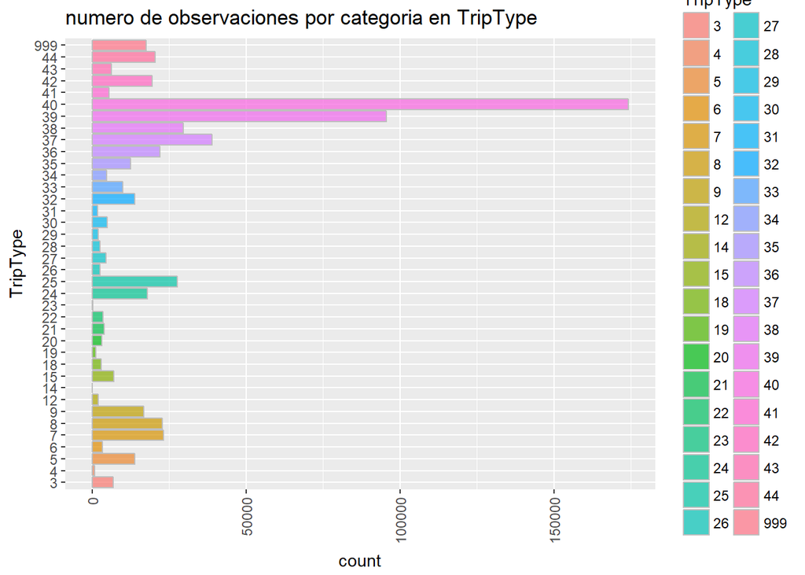

```r
ggplot(train, aes(TripType, fill = TripType)) +
  geom_bar(colour = 'grey', alpha = 0.7) +
  theme(axis.text.x = element_text(angle = 90, vjust = 0.5, hjust=1)) +
  labs(title = "numero de observaciones por categoria en TripType", x = "TripType", y = "count") +
  coord_flip()
```

### VisitNumber

`VisitNumber` es una variable categórica

- Cuntos `VisitNumber`s hay en los datasets?

```r
print(paste('numero de categorias:', length(levels(as.factor(train$VisitNumber)))))
```

```
## [1] "numero de categorias: 95674"
```

```r
print(paste('numero de categorias:', length(levels(as.factor(test$VisitNumber)))))
```

```
## [1] "numero de categorias: 95674"
```

```r
print(paste('numero de categorias:', length(levels(total$VisitNumber))))
```

```
## [1] "numero de categorias: 191348"
```

- Cul es el resumen del nºmero de observaciones por `VisitNumber` en el dataset `total`?

```r
summary(as.data.frame(table(total$VisitNumber))$Freq)
```

```
##    Min. 1st Qu.  Median    Mean 3rd Qu.    Max.
##   1.000   2.000   4.000   6.798   8.000 209.000
```

### Weekday

`Weekday` es una variable categórica

- Cuntas observaciones por `Weekday` hay en el dataset `total`?

```r
summary(total$Weekday)
```

```
##    Friday    Monday  Saturday    Sunday  Thursday   Tuesday Wednesday
##    191011    168304    246070    267208    138240    146271    143596
```

### Upc

`Upc` es una variable categórica

- Cuntas categorías tiene `Upc` en los datasets?

```r
print(paste('numero de categorias:', length(levels(as.factor(train$Upc)))))
```

```
## [1] "numero de categorias: 97714"
```

```r
print(paste('numero de categorias:', length(levels(as.factor(test$Upc)))))
```

```
## [1] "numero de categorias: 98147"
```

```r
print(paste('numero de categorias:', length(levels(as.factor(total$Upc)))))
```

```
## [1] "numero de categorias: 124693"
```

Vemos que hay demasiados `Upc` distintos. Adems, existen varios `Upc` en `test` que no estn en `train`.

### FinelineNumber

`FinelineNumber` es una variable categórica

- Cuntas categorías tiene `FinelineNumber` en los datasets?

```r
print(paste('numero de categorias:', length(levels(as.factor(train$FinelineNumber)))))
```

```
## [1] "numero de categorias: 5195"
```

```r
print(paste('numero de categorias:', length(levels(as.factor(test$FinelineNumber)))))
```

```
## [1] "numero de categorias: 5203"
```

```r
print(paste('numero de categorias:', length(levels(as.factor(total$FinelineNumber)))))
```

```
## [1] "numero de categorias: 5353"
```

Vemos que hay demasiados `FinelineNumber` distintos. Adems, existen varios `FinelineNumber` en `test` que no estn en `train`.

### DepartmentDescription

`DepartmentDescription` es una variable categórica

- Cuántas categorías tiene `DepartmentDescription` en los datasets?

```r
print(paste('numero de categorias:', length(levels(as.factor(train$DepartmentDescription)))))
```

```
## [1] "numero de categorias: 69"
```

```r
print(paste('numero de categorias:', length(levels(as.factor(test$DepartmentDescription)))))
```

```
## [1] "numero de categorias: 68"
```

```r
print(paste('numero de categorias:', length(levels(total$DepartmentDescription))))
```

```
## [1] "numero de categorias: 69"
```

- Qué categorías y cuntas observaciones por categoría tiene `DepartmentDescription` en el dataset `total`?

```r
summary(total$DepartmentDescription)
```

```
##                  1-HR PHOTO                 ACCESSORIES
##                         788                        2738
##                  AUTOMOTIVE                      BAKERY
##                       10873                       14333
##             BATH AND SHOWER                      BEAUTY
##                        9247                       30088
##                     BEDDING         BOOKS AND MAGAZINES
##                        4510                        1901
##                   BOYS WEAR            BRAS & SHAPEWEAR
##                        7778                        4054
##        CAMERAS AND SUPPLIES     CANDY, TOBACCO, COOKIES
##                         468                       20118
##                 CELEBRATION                  COMM BREAD
##                       17333                       30932
##              CONCEPT STORES               COOK AND DINE
##                          84                       15388
##                       DAIRY                 DSD GROCERY
##                       88644                      137192
##                 ELECTRONICS          FABRICS AND CRAFTS
##                        6551                       10221
##          FINANCIAL SERVICES                FROZEN FOODS
##                       21580                       42991
##                   FURNITURE  GIRLS WEAR, 4-6X  AND 7-14
##                         921                        9144
##           GROCERY DRY GOODS                    HARDWARE
##                      142737                        9798
##      HEALTH AND BEAUTY AIDS                  HOME DECOR
##                           2                        8236
##             HOME MANAGEMENT     HORTICULTURE AND ACCESS
##                       12646                        5933
##    HOUSEHOLD CHEMICALS/SUPP       HOUSEHOLD PAPER GOODS
##                       49482                       31916
##         IMPULSE MERCHANDISE              INFANT APPAREL
##                       57153                       12610
## INFANT CONSUMABLE HARDLINES      JEWELRY AND SUNGLASSES
##                       21316                        5003
##                LADIES SOCKS                  LADIESWEAR
##                        1537                       17740
##       LARGE HOUSEHOLD GOODS             LAWN AND GARDEN
##                         180                       10790
```

[output cut: 15 more lines]

```
##                        5706                        1355
##          PLUS AND MATERNITY             PRE PACKED DELI
##                        1235                       18328
##                     PRODUCE                     SEAFOOD
##                      102043                        4058
##                    SEASONAL                SERVICE DELI
##                          76                       20176
##               SHEER HOSIERY                       SHOES
##                         948                       12313
##       SLEEPWEAR/FOUNDATIONS              SPORTING GOODS
##                        4839                       10118
##          SWIMWEAR/OUTERWEAR                        TOYS
##                        1730                       12242
##                    WIRELESS
##                        3708
```

Antes no identificamos NULLs en ninguna columna, pero existe una categoría ‘NULL’ en `DepartmentDescription`.

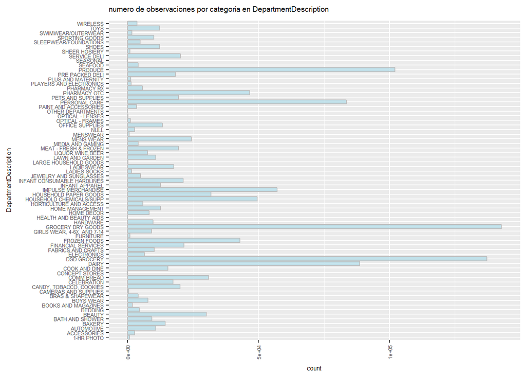

```r
ggplot(total, aes(DepartmentDescription)) +
  geom_bar(colour = 'grey', fill = 'lightblue', alpha = 0.7) +
  theme(axis.text.x = element_text(angle = 90, vjust = 0.5, hjust=1)) +
  theme(text = element_text(size = 6)) +
  labs(title = "numero de observaciones por categoria en DepartmentDescription", x = "DepartmentDescription", y = "count") +
  coord_flip()
```

### ScanCount

`ScanCount` es una variable numérica

- Cuál es el resumen de `ScanCount` en el dataset `total`?

```r
summary(total$ScanCount)
```

```
##    Min. 1st Qu.  Median    Mean 3rd Qu.    Max.
## -21.000   1.000   1.000   1.109   1.000  71.000
```

- Qué porcentaje de devoluciones hay en dataset `total`?

```r
paste('numero total de devoluciones', sum(total$ScanCount[total$ScanCount < 0]))
```

```
## [1] "numero total de devoluciones -34178"
```

```r
paste('numero total de transacciones', sum(abs(total$ScanCount)))
```

```
## [1] "numero total de transacciones 1510574"
```

```r
paste('pct de devoluciones', - sum(total$ScanCount[total$ScanCount < 0]) / sum(abs(total$ScanCount)))
```

```
## [1] "pct de devoluciones 0.02262583627151"
```

## Preparación

En esta sección preparamos los datos para los siguientes pasos.

Nota.- La libreria ReadR, con la instrucción read_csv genera tibbles con *correciones* automaticas

```r
train_tibb <- read_csv("C:/Users/Eduardo/Desktop/Documentos Finales 1er Semestre/Mineria y Analisis de Datos/Examen Final/Trabajo en Equipo/proyecto_final_intro_to_ds_2017/michelle/walmart_train.csv")
test_tibb <- read_csv("C:/Users/Eduardo/Desktop/Documentos Finales 1er Semestre/Mineria y Analisis de Datos/Examen Final/Trabajo en Equipo/proyecto_final_intro_to_ds_2017/michelle/walmart_test.csv")
total_tibb <- bind_rows(train_tibb, test_tibb)
```

El parseo de `read_csv` no identifica ningºn problema en los datasets.

```r
problems(train_tibb)
```

```
## # tibble [0 x 4]
## # ... with 4 variables: row <int>, col <int>, expected <chr>, actual <chr>
```

```r
problems(test_tibb)
```

```
## # tibble [0 x 4]
## # ... with 4 variables: row <int>, col <int>, expected <chr>, actual <chr>
```

```r
problems(total_tibb)
```

```
## # tibble [0 x 4]
## # ... with 4 variables: row <int>, col <int>, expected <chr>, actual <chr>
```

**total_prep**

```r
total_prep <- total_tibb
total_prep1<- total_tibb
total_prep %<>%
  mutate(TripType = as.factor(TripType)) %>%
  mutate(VisitNumber = as.factor(VisitNumber)) %>%
  mutate(Weekday = as.factor(Weekday)) %>%
  mutate(ScanCount = as.numeric(ScanCount)) %>%
  mutate(Upc = as.factor(Upc)) %>%
  mutate(FinelineNumber = as.factor(FinelineNumber)) %>%
  mutate(DepartmentDescription = as.factor(DepartmentDescription))

glimpse(total_prep)
```

```
## Observations: 1,300,700
## Variables: 7
## $ TripType              <fctr> 999, 30, 30, 26, 26, 26, 26, 26, 26, 26...
## $ VisitNumber           <fctr> 5, 7, 7, 8, 8, 8, 8, 8, 8, 8, 8, 8, 8, ...
## $ Weekday               <fctr> Friday, Friday, Friday, Friday, Friday,...
## $ Upc                   <fctr> 68113152929, 60538815980, 7410811099, 2...
## $ ScanCount             <dbl> -1, 1, 1, 2, 2, 2, 1, 1, 1, -1, 1, 2, 1,...
## $ DepartmentDescription <fctr> FINANCIAL SERVICES, SHOES, PERSONAL CAR...
## $ FinelineNumber        <fctr> 1000, 8931, 4504, 3565, 1017, 1017, 101...
```

```r
saveRDS(total_prep, 'total_prep.RDS')
```

**train_prep**

```r
train_prep <- train_tibb

train_prep %<>%
  mutate(TripType = factor(TripType, levels(total_prep$TripType))) %>%
  mutate(VisitNumber = factor(VisitNumber, levels(total_prep$VisitNumber))) %>%
  mutate(Weekday = factor(Weekday, levels(total_prep$Weekday))) %>%
  mutate(ScanCount = as.numeric(ScanCount)) %>%
  mutate(Upc = factor(Upc, levels(total_prep$Upc))) %>%
  mutate(FinelineNumber = factor(FinelineNumber, levels(total_prep$FinelineNumber))) %>%
  mutate(DepartmentDescription = factor(DepartmentDescription, levels(total_prep$DepartmentDescription)))

glimpse(train_prep)
```

```
## Observations: 647,054
## Variables: 7
## $ TripType              <fctr> 999, 30, 30, 26, 26, 26, 26, 26, 26, 26...
## $ VisitNumber           <fctr> 5, 7, 7, 8, 8, 8, 8, 8, 8, 8, 8, 8, 8, ...
## $ Weekday               <fctr> Friday, Friday, Friday, Friday, Friday,...
## $ Upc                   <fctr> 68113152929, 60538815980, 7410811099, 2...
## $ ScanCount             <dbl> -1, 1, 1, 2, 2, 2, 1, 1, 1, -1, 1, 2, 1,...
## $ DepartmentDescription <fctr> FINANCIAL SERVICES, SHOES, PERSONAL CAR...
## $ FinelineNumber        <fctr> 1000, 8931, 4504, 3565, 1017, 1017, 101...
```

```r
saveRDS(train_prep, 'train_prep.RDS')
```

**test_prep**

```r
test_prep <- test_tibb

test_prep %<>%
  #mutate(TripType = factor(TripType, levels(total_prep$TripType))) %>%
  mutate(VisitNumber = factor(VisitNumber, levels(total_prep$VisitNumber))) %>%
  mutate(Weekday = factor(Weekday, levels(total_prep$Weekday))) %>%
  mutate(ScanCount = as.numeric(ScanCount)) %>%
  mutate(Upc = factor(Upc, levels(total_prep$Upc))) %>%
  mutate(FinelineNumber = factor(FinelineNumber, levels(total_prep$FinelineNumber))) %>%
  mutate(DepartmentDescription = factor(DepartmentDescription, levels(total_prep$DepartmentDescription)))

glimpse(test_prep)
```

```
## Observations: 653,646
## Variables: 6
## $ VisitNumber           <fctr> 1, 1, 1, 1, 2, 2, 2, 2, 3, 3, 4, 6, 6, ...
## $ Weekday               <fctr> Friday, Friday, Friday, Friday, Friday,...
## $ Upc                   <fctr> 72503389714, 1707710732, 89470001026, 8...
## $ ScanCount             <dbl> 1, 1, 1, 1, 1, 1, 1, 1, 1, -1, 1, 1, -1,...
## $ DepartmentDescription <fctr> SHOES, DAIRY, DAIRY, GROCERY DRY GOODS,...
## $ FinelineNumber        <fctr> 3002, 1526, 1431, 3555, 4408, 5019, 802...
```

```r
saveRDS(test_prep, 'test_prep.RDS')
```

## Exploración multivariada

En esta sección hacemos la exploración multivariada de los datasets.

### Visit Number + ScanCount

**total_Visits**

```r
total_Visits <- total %>%
  select(VisitNumber, Weekday, ScanCount) %>%
  group_by(VisitNumber, Weekday) %>%
  summarize(VisitRows = n(), VisitItems = sum(ScanCount))
```

- Cuál es el resumen del número de items comprados por `VisitNumber` en el dataset `total`?

```r
summary(total_Visits$VisitItems)
```

```
##    Min. 1st Qu.  Median    Mean 3rd Qu.    Max.
## -52.000   2.000   4.000   7.537   9.000 417.000
```

### VisitNumber + ScanCode + Weekday

- Cuántas visitas hay por `Weekday` en el dataset `total`?

```r
table(total_Visits$Weekday)
```

```
##
##    Friday    Monday  Saturday    Sunday  Thursday   Tuesday Wednesday
##     30288     24232     33760     34181     22540     23009     23338
```

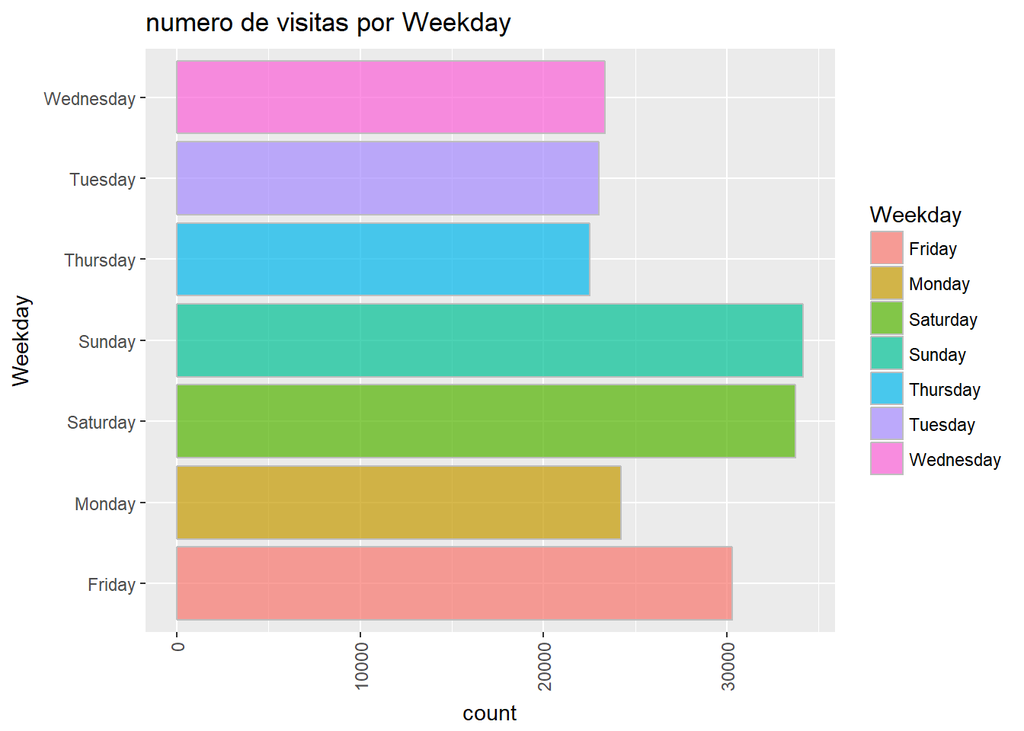

```r
total_Visits %>%
  ggplot(aes(Weekday, fill = Weekday)) +
  geom_bar(colour = 'grey', alpha = 0.7) +
  theme(axis.text.x = element_text(angle = 90, vjust = 0.5, hjust=1)) +
  labs(title = "numero de visitas por Weekday", x = "Weekday", y = "count") +
  coord_flip()
```

- Cuántos items se compran por visita por `Weekday` en el dataset `total`?

Filtramos aquellas visitas con más de 125 items.

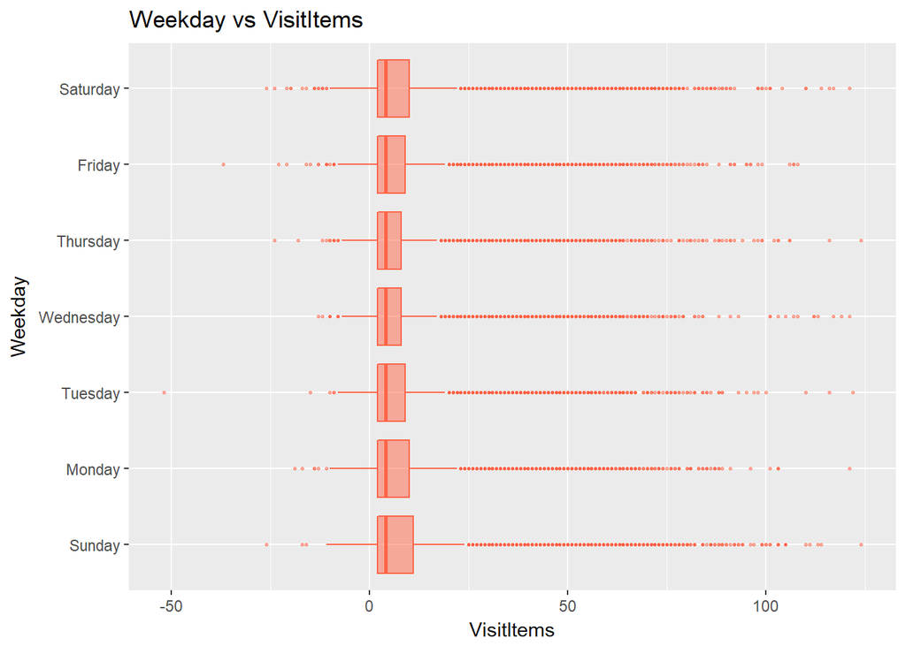

```r
total_Visits$Weekday<-factor(total_Visits$Weekday,levels = c('Sunday','Monday','Tuesday','Wednesday','Thursday','Friday','Saturday'))
total_Visits%>% arrange(desc(Weekday)) %>%
  filter(VisitItems < 125) %>%
  ggplot(aes(x = Weekday, y = VisitItems)) +
  geom_boxplot(outlier.size = 0.5, fill = 'tomato', colour = 'tomato', alpha = 0.5) +
  ggtitle("Weekday vs VisitItems") +
  coord_flip()
```

### VisitNumber + ScanCode + TripType

**train_Visits**

```r
train_Visits <- train %>%
  select(TripType, VisitNumber, Weekday, ScanCount) %>%
  group_by(TripType, VisitNumber, Weekday) %>%
  summarize(VisitRows = n(), VisitItems = sum(ScanCount))
```

### VisitNumber + ScanCode + DepartmentDescription

**total_Depts**

```r
total_Depts <- total %>%
  select(VisitNumber, Weekday, ScanCount, DepartmentDescription) %>%
  group_by(VisitNumber, Weekday, DepartmentDescription) %>%
  summarize(DeptRows = n(), DeptItems = sum(ScanCount))
```

- Cuántas visitas hay por Departamento en el dataset `total`?

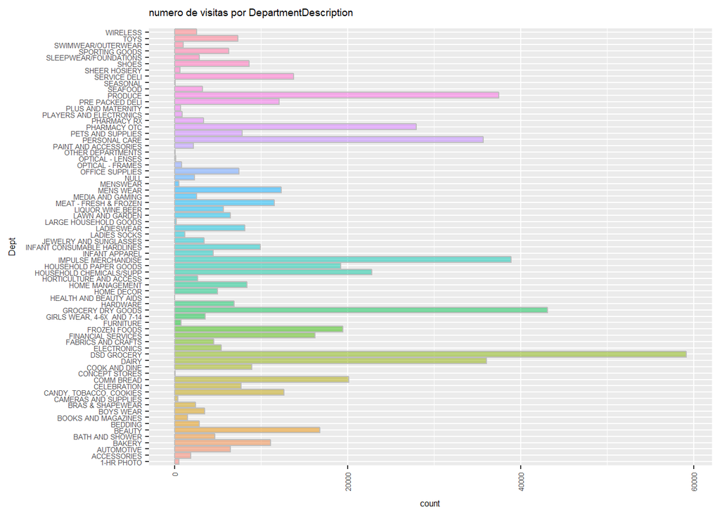

```r
total_Depts %>%
  group_by(DepartmentDescription) %>%
  summarize(n = n_distinct(VisitNumber)) %>%
  ggplot(aes(x = DepartmentDescription, y = n, fill = DepartmentDescription)) +
  geom_bar(stat = 'identity', colour = 'grey', alpha = 0.5) +
  coord_flip() +
  theme(axis.text.x = element_text(angle = 90, vjust = 0.5, hjust=1)) +
  theme(text = element_text(size = 6)) +
  labs(title = "numero de visitas por DepartmentDescription", x = "Dept", y = "count") +
  theme(legend.position="none")
```

- Cuántos items se compran por visita por `DepartmentDescription` en el dataset `train`?

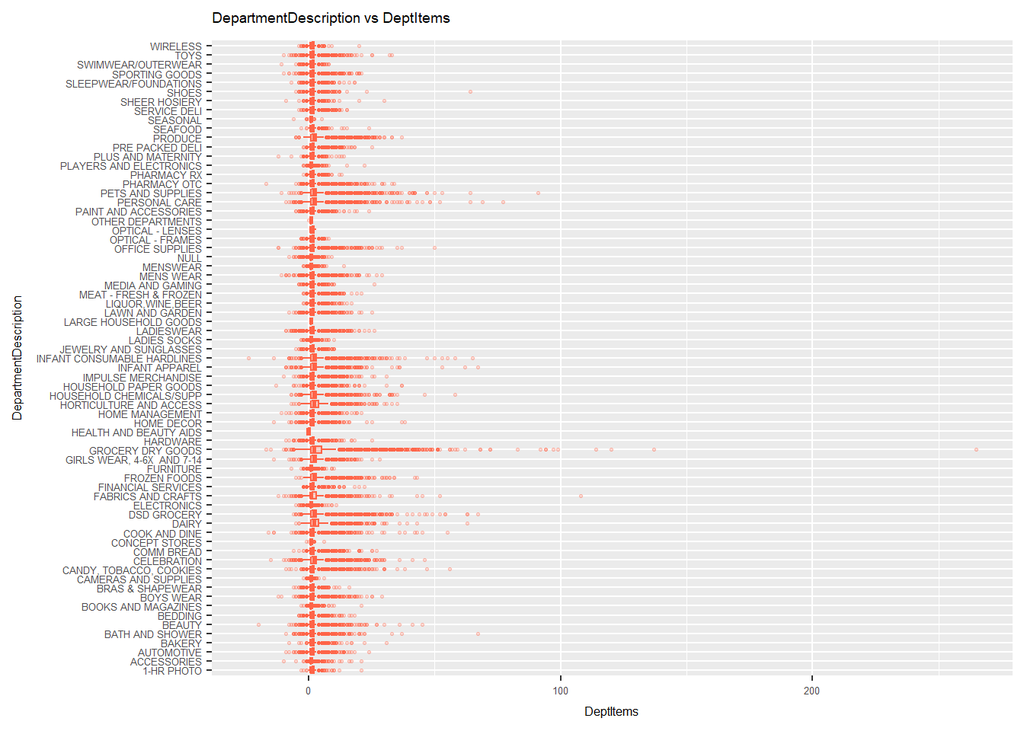

```r
total_Depts %>%
  ggplot(aes(x = DepartmentDescription, y = DeptItems)) +
  geom_boxplot(outlier.size = 0.5, fill = 'tomato', colour = 'tomato', alpha = 0.25) +
  coord_flip() +
  ggtitle("DepartmentDescription vs DeptItems") +
  theme(text = element_text(size = 6))
```

- En cuántos Departamentos se compra en cada visita en el dataset `total`?

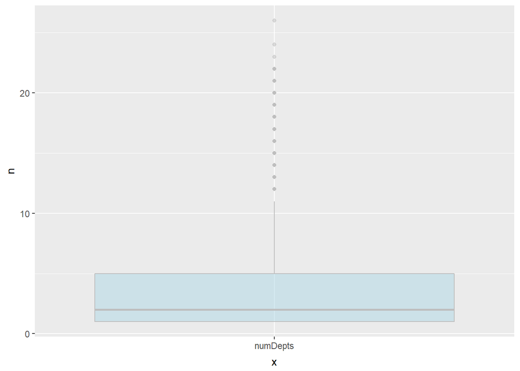

```r
total_Depts %>%
  group_by(VisitNumber) %>%
  summarize(n = n_distinct(DepartmentDescription)) %>%
  ggplot(aes(x = 'numDepts', y = n)) +
  geom_boxplot(fill = 'lightblue', colour = 'grey', alpha = 0.5)
```

### VisitNumber + ScanCode + Weekday + TripType

- Obtenemos la distribución de visitas por `Weekday` para cada `TripType`

Cada renglón representa la distribución de cada TripType.

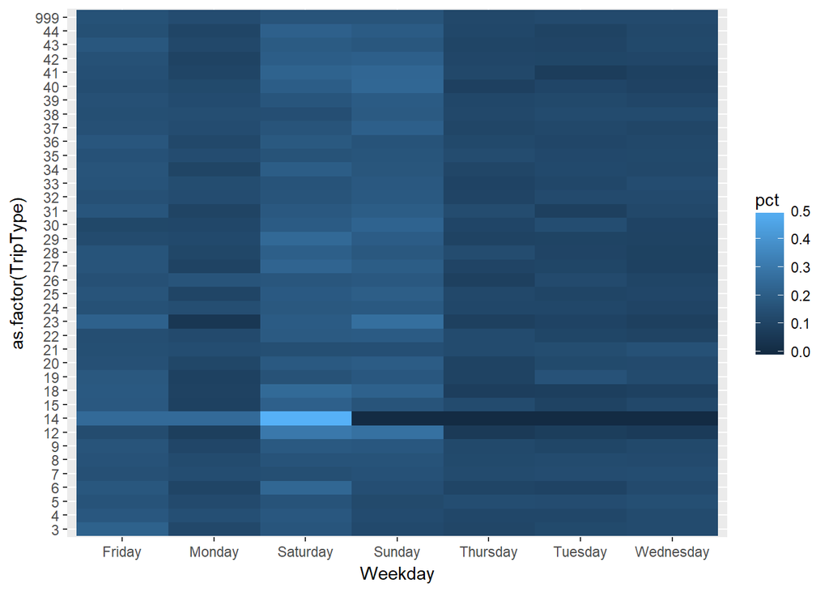

```r
tt <- as.matrix(table(train_Visits$TripType, train_Visits$Weekday))
tt_TripType <- tt / apply(tt, 1, sum)
tt_TripType <- melt(tt_TripType)
colnames(tt_TripType) <- c('TripType', 'Weekday', 'pct')
ggplot(tt_TripType, aes(x = Weekday, y = as.factor(TripType), fill = pct)) +
  geom_raster()
```

- Obtenemos la distribución de visitas por `TripType` para cada `Weekday`

Cada columna representa la distribución de cada Weekday.

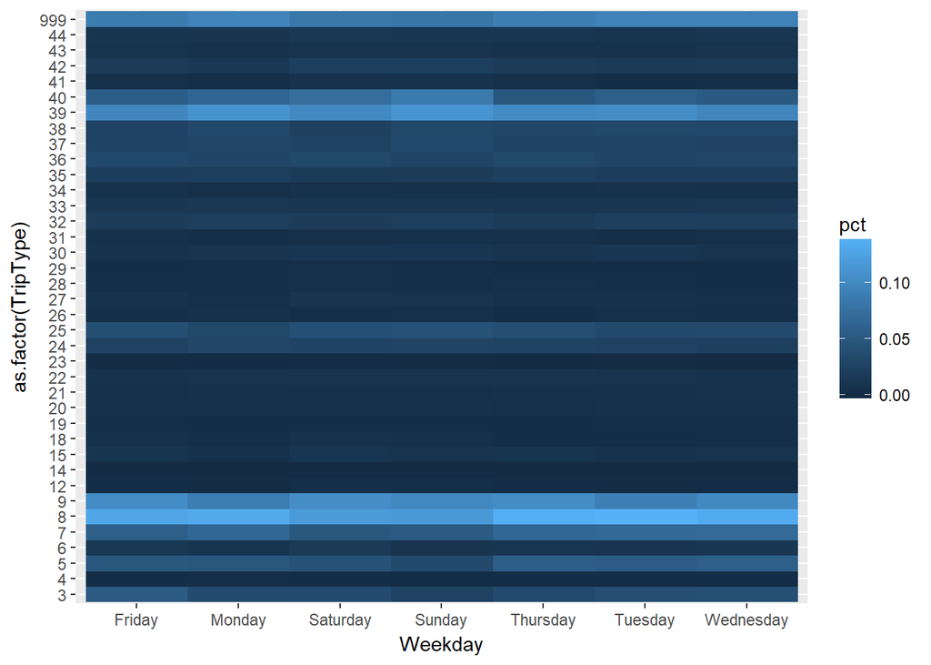

```r
tt <- as.matrix(table(train_Visits$Weekday, train_Visits$TripType))
tt_Weekday <- tt / apply(tt, 1, sum)
tt_Weekday <- melt(tt_Weekday)
colnames(tt_Weekday) <- c('Weekday', 'TripType', 'pct')
ggplot(tt_Weekday, aes(x = Weekday, y = as.factor(TripType), fill = pct)) +
  geom_raster()
```

Concluimos que `Weekday` no distingue entre distintos `TripType`s.

### DepartmentDescription + TripType

- Obtenemos la distribución de observaciones por `TripType` para cada `DepartmentDescription`

Cada columna representa la distribución de cada `DepartmentDescription`.

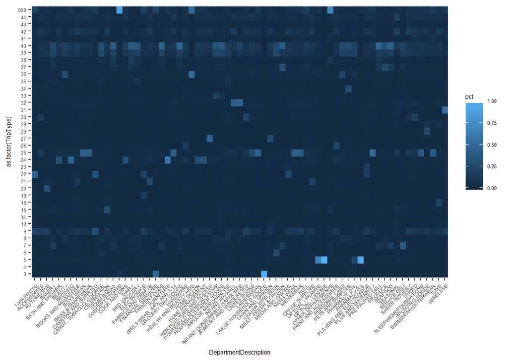

```r
tt <- as.matrix(table(train$DepartmentDescription, train$TripType))
tt <- tt / apply(tt, 1, sum)
tt <- melt(tt)
colnames(tt) <- c('DepartmentDescription', 'TripType', 'pct')

ggplot(tt, aes(x = DepartmentDescription, y = as.factor(TripType), fill = pct)) +
  geom_raster() +
  theme(axis.text.x = element_text(angle = 45, hjust=1)) +
  theme(text = element_text(size = 6))
```

Vemos que en todos los departamentos hay una importante concentración de viajes de tipo 40, 39, 9, y 8. Esto hace sentido porque la mayoría de los viajes son de estos tipos.

- Obtenemos la distribución de observaciones por `DepartmentDescription` para cada `TripType`

Cada renglón representa la distribución de cada TripType.

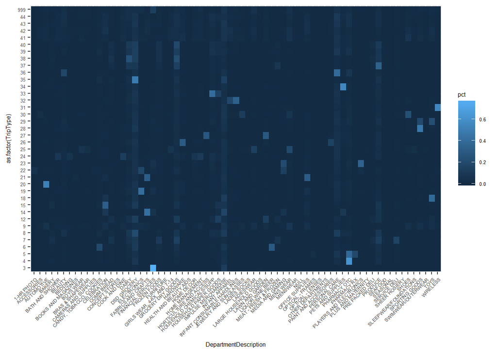

```r
tt <- as.matrix(table(train$TripType, train$DepartmentDescription))
tt_TripType <- tt / apply(tt, 1, sum)
tt_TripType <- melt(tt_TripType)
colnames(tt_TripType) <- c('TripType', 'DepartmentDescription', 'pct')

ggplot(tt_TripType, aes(x = DepartmentDescription, y = as.factor(TripType), fill = pct)) +
  geom_raster()  +
  theme(axis.text.x = element_text(angle = 45, hjust=1)) +
  theme(text = element_text(size = 6))
```

Podemos ver que:

- las observaciones tipo 3 se concentra en *Financial Services*
- las observaciones tipo 14 se concentran en *Fabrics and Crafts*

Concluimos que `DepartmentDescription` distingue entre `TripTypes`

## Limpieza e Imputación

En esta sección hacemos la limpieza e imputación de los datasets.

### Validaciones

- Existe un único `TripType` por cada `VisitNumber` en el dataset `train`?

Si, no hay ningn error.

```r
validacion <- train %>%
  distinct(TripType, VisitNumber) %>%
  group_by(VisitNumber) %>%
  summarize(count = n_distinct(TripType)) %>%
  mutate(error = (count != 1))

validacion %>%
  group_by(error) %>%
  summarize(n())
```

```
## # A tibble: 1 x 2
##   error `n()`
##   <lgl> <int>
## 1 FALSE 95674
```

- Existe un nico `Weekday` por cada `VisitNumber` en el dataset `total`?

Si, no hay ningn error.

```r
validacion <- total %>%
  distinct(VisitNumber, Weekday) %>%
  group_by(VisitNumber) %>%
  summarize(count = n_distinct(Weekday)) %>%
  mutate(error = (count != 1))

validacion %>%
  group_by(error) %>%
  summarize(n())
```

```
## # A tibble: 1 x 2
##   error  `n()`
##   <lgl>  <int>
## 1 FALSE 191348
```

**Productos**

```r
products <- total %>%
  select(Upc, FinelineNumber, DepartmentDescription) %>%
  group_by(Upc, FinelineNumber, DepartmentDescription) %>%
  summarize(num = n())
```

- Existe un único `FinelineNumber` por cada `Upc`?

```r
validacion <- products %>%
  group_by(Upc) %>%
  summarize(count = n_distinct(FinelineNumber)) %>%
  mutate(error = (count != 1))

validacion %>%
  group_by(error) %>%
  summarize(n())
```

```
## # A tibble: 2 x 2
##   error  `n()`
##   <lgl>  <int>
## 1 FALSE 124667
## 2  TRUE     27
```

- Cuántas observaciones en `total` contienen `Upc`s que tienen más de un `FinelineNumber`?

```r
error <- validacion$Upc[validacion$error]

dim(total %>% filter(Upc %in% error))
```

```
## [1] 180   6
```

- Existe un único `DepartmentDescription` por cada `Upc`?

```r
validacion <- products %>%
  group_by(Upc) %>%
  summarize(count = n_distinct(DepartmentDescription)) %>%
  mutate(error = (count != 1))

validacion %>%
  group_by(error) %>%
  summarize(n())
```

```
## # A tibble: 2 x 2
##   error  `n()`
##   <lgl>  <int>
## 1 FALSE 124692
## 2  TRUE      2
```

- ¿Quíen `Upc` tiene más de un `DepartmentDescription`?

```r
error <- validacion$Upc[validacion$error]

products %>%
  distinct(Upc, DepartmentDescription) %>%
  filter(Upc %in% error)
```

```
## # A tibble: 4 x 3
## # Groups:   Upc, FinelineNumber [3]
##           Upc FinelineNumber DepartmentDescription
##         <dbl>          <int>                <fctr>
## 1 85651600204           3350           DSD GROCERY
## 2 85651600204           7129               PRODUCE
## 3          NA             NA                  NULL
## 4          NA             NA           PHARMACY RX
```

- Existe un único `DepartmentDescription` por cada `FinelineNumber`?

Hay muchos `FinelineNumber`s que corresponden a diferentes `DepartmentDescription`s

```r
validacion <- products %>%
  group_by(FinelineNumber) %>%
  summarize(count = n_distinct(DepartmentDescription)) %>%
  mutate(error = (count != 1))

validacion %>%
  group_by(error) %>%
  summarize(n())
```

```
## # A tibble: 2 x 2
##   error `n()`
##   <lgl> <int>
## 1 FALSE  2688
## 2  TRUE  2666
```

- Cuántas observaciones en `total` contienen `FinelineNumbers`s que tienen más de un `DepartmentDescription`?

Esto ocurre en casi un millón de observaciones, es decir en el 75% de `total`.

```r
error <- validacion$FinelineNumber[validacion$error]

dim(total %>% filter(FinelineNumber %in% error))
```

```
## [1] 992783      6
```

### Campos vacíos

- Qué entradas en `UPC` y `FinelineNumber` tienen NAs?

Las entradas que tienen NAs en `UPC` son las mismas que tienen NAs en `FinelineNumber`.

```r
products[is.na(products$Upc), ]
```

```
## # A tibble: 2 x 4
## # Groups:   Upc, FinelineNumber [1]
##     Upc FinelineNumber DepartmentDescription   num
##   <dbl>          <int>                <fctr> <int>
## 1    NA             NA                  NULL  2689
## 2    NA             NA           PHARMACY RX  5426
```

```r
products[is.na(products$FinelineNumber), ]
```

```
## # A tibble: 2 x 4
## # Groups:   Upc, FinelineNumber [1]
##     Upc FinelineNumber DepartmentDescription   num
##   <dbl>          <int>                <fctr> <int>
## 1    NA             NA                  NULL  2689
## 2    NA             NA           PHARMACY RX  5426
```

Las entradas que no tienen `DepartmentDescription` tampoco tienen `Upc` y `FinelineNumber`.

```r
products[products$DepartmentDescription == 'NULL', ]
```

```
## # A tibble: 1 x 4
## # Groups:   Upc, FinelineNumber [1]
##     Upc FinelineNumber DepartmentDescription   num
##   <dbl>          <int>                <fctr> <int>
## 1    NA             NA                  NULL  2689
```

Distribución entre NULL `DepartmentDescription` y `TripType`

```r
DepTripType<-total_prep%>%dplyr::mutate(Items=ScanCount)%>%dplyr::filter(DepartmentDescription=="NULL")%>%dplyr::group_by(DepartmentDescription,TripType)%>%dplyr::summarise(TotalItemSold=sum(Items))%>%dplyr::arrange(desc(TotalItemSold))
DepTripType$NULLDpt<-ifelse(is.na(DepTripType$TripType),'Yes','No')
DepTripType$NULLDpt<-factor(DepTripType$NULLDpt,levels = c('Yes','No'))
head(DepTripType)
```

```
## # A tibble: 6 x 4
## # Groups:   DepartmentDescription [1]
##   DepartmentDescription TripType TotalItemSold NULLDpt
##                  <fctr>   <fctr>         <dbl>  <fctr>
## 1                  NULL     <NA>           986     Yes
## 2                  NULL       40           192      No
## 3                  NULL       25           126      No
## 4                  NULL       39           118      No
## 5                  NULL        9            83      No
## 6                  NULL        8            76      No
```

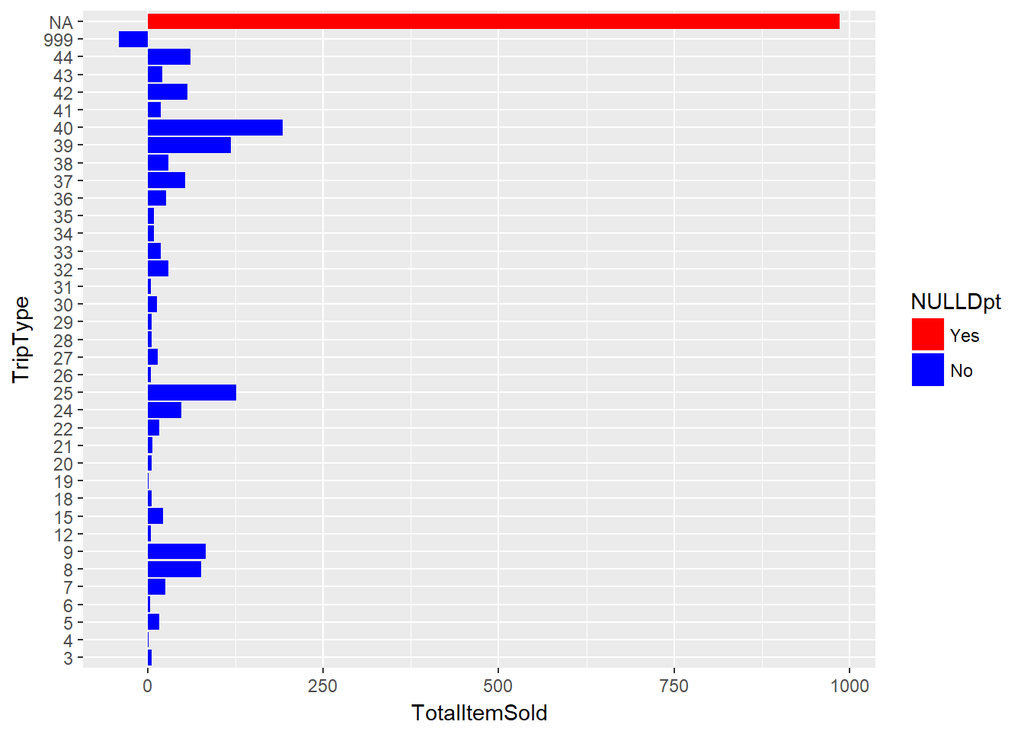

```r
ggplot(data=DepTripType)+geom_bar(mapping= aes(x=TripType, y=TotalItemSold, fill=NULLDpt), stat="identity") +

 scale_fill_manual(values=c('red','blue'))+coord_flip()
```

```r
DepTripType$TripTypeNA<-ifelse(is.na(DepTripType$TripType),'Yes','No')
DepTripType%>%dplyr::group_by(NULLDpt,TripTypeNA)%>%dplyr::summarise(NetItemsSold=sum(TotalItemSold))
```

```
## # A tibble: 2 x 3
## # Groups:   NULLDpt [?]
##   NULLDpt TripTypeNA NetItemsSold
##    <fctr>      <chr>        <dbl>
## 1     Yes        Yes          986
## 2      No         No         1089
```

¿PHARMACY RX, tendrá observaciones sin `NA`s ?

```r
a<-products%>%filter(DepartmentDescription=="PHARMACY RX") #[,21:26]
a[21:26,]
```

```
## # A tibble: 6 x 4
## # Groups:   Upc, FinelineNumber [6]
##           Upc FinelineNumber DepartmentDescription   num
##         <dbl>          <int>                <fctr> <int>
## 1 68113131176           5615           PHARMACY RX     6
## 2 68113131177           5615           PHARMACY RX     3
## 3 68113131178           5615           PHARMACY RX    14
## 4 68113131179           5615           PHARMACY RX     9
## 5 68130604702           1335           PHARMACY RX     2
## 6          NA             NA           PHARMACY RX  5426
```

```r
rm(a)
```

Parece que los $5,426$ items en *Na* se refieren a un`Upc` o codigo de barrras no identificado, por lo que sería viable codificarlo como $0$ tanto el `Upc`como el `FineLineNumber`asociado, para catalogarlo como una nueva categoría

**train_clean**

Antes de comenzar con los modelos de selección es necesario dejar la base en formato TidyR. Es importante mencionar que el nivel más granular de la base `train_prep` es el número de `Upc`(código de barras). Un mismo codigo de barra puede tener varios `ScanCount`s o items comprados con el mismo código

Usaremos la `tabla train_prep`. Dado que no contamos con la variable dependiente en el conjunto de prueba,vamos a generar un corte a la información de entrenamiento para poder en ese conjunto hacer *cross-validation*

Antes generamos una variable que contenga información referente al porcentaje de las compras totales que se hizo en cada departamento durante el viaje

```r
str(train_prep)
```

```
## Classes 'tbl_df', 'tbl' and 'data.frame':    647054 obs. of  7 variables:
##  $ TripType             : Factor w/ 38 levels "3","4","5","6",..: 38 23 23 19 19 19 19 19 19 19 ...
##  $ VisitNumber          : Factor w/ 191348 levels "1","2","3","4",..: 5 7 7 8 8 8 8 8 8 8 ...
##  $ Weekday              : Factor w/ 7 levels "Friday","Monday",..: 1 1 1 1 1 1 1 1 1 1 ...
##  $ Upc                  : Factor w/ 124693 levels "834","837","3032",..: 81278 71199 49823 11426 9797 9813 9796 42457 11451 11418 ...
##  $ ScanCount            : num  -1 1 1 2 2 2 1 1 1 -1 ...
##  $ DepartmentDescription: Factor w/ 69 levels "1-HR PHOTO","ACCESSORIES",..: 21 64 52 51 51 51 51 51 51 51 ...
##  $ FinelineNumber       : Factor w/ 5353 levels "0","1","2","3",..: 765 5022 2923 2384 782 782 782 1887 2920 2384 ...
```

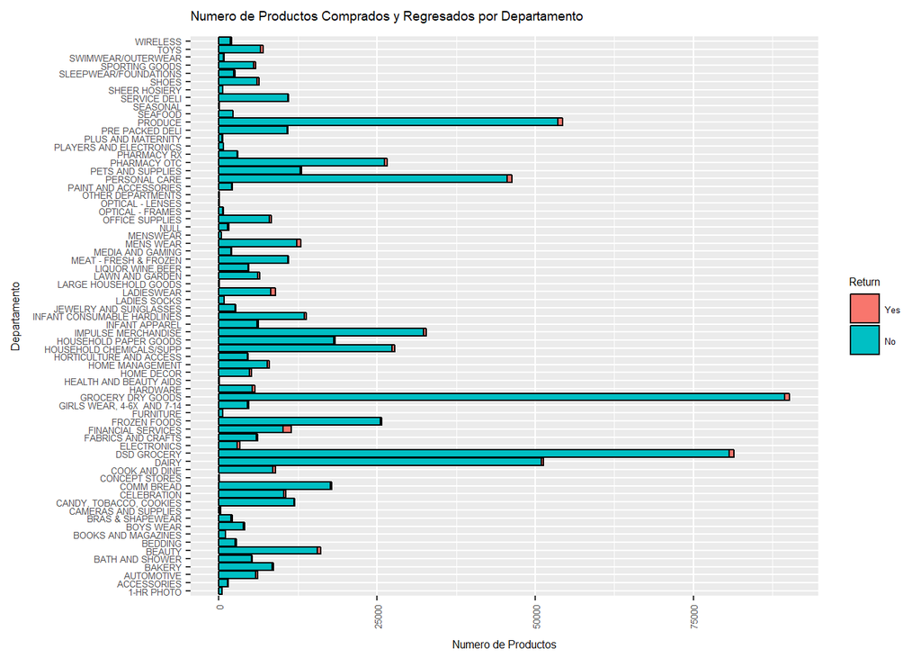

```r
train_prep$Upc<-ifelse(is.na(train_prep$Upc),0,train_prep$Upc)
train_prep$FinelineNumber<-NULL
train_prep$Return<-ifelse(train_prep$ScanCount<0,'Yes','No')
train_prep$Return<-factor(train_prep$Return,levels = c("Yes","No"))
p<-ggplot(data=train_prep)+geom_bar(mapping=aes(x=DepartmentDescription,y=Return,fill = ScanCount),stat="summary",fun.y="sum",position="dodge")+coord_flip()
Aux<-train_prep%>%dplyr::group_by(DepartmentDescription,Return)%>%dplyr::summarise(ItemsBoughtReturn=sum(ScanCount),ProductsBoughtReturn=n_distinct(ScanCount))
Aux$ItemsBoughtReturn<-ifelse(Aux$ItemsBoughtReturn>0,Aux$ItemsBoughtReturn,Aux$ItemsBoughtReturn*-1)
ggplot(data=Aux, aes(x=DepartmentDescription, y=ItemsBoughtReturn, fill=Return))+geom_bar(colour="black", stat="identity") +
  theme(axis.text.x = element_text(angle = 90, vjust = 0.5, hjust=1)) +
  theme(text = element_text(size = 6)) +
  labs(title = "Numero de Productos Comprados y Regresados por Departamento", x = "Departamento", y = "Numero de Productos") +
  coord_flip()
```

```r
rm(Aux)
```

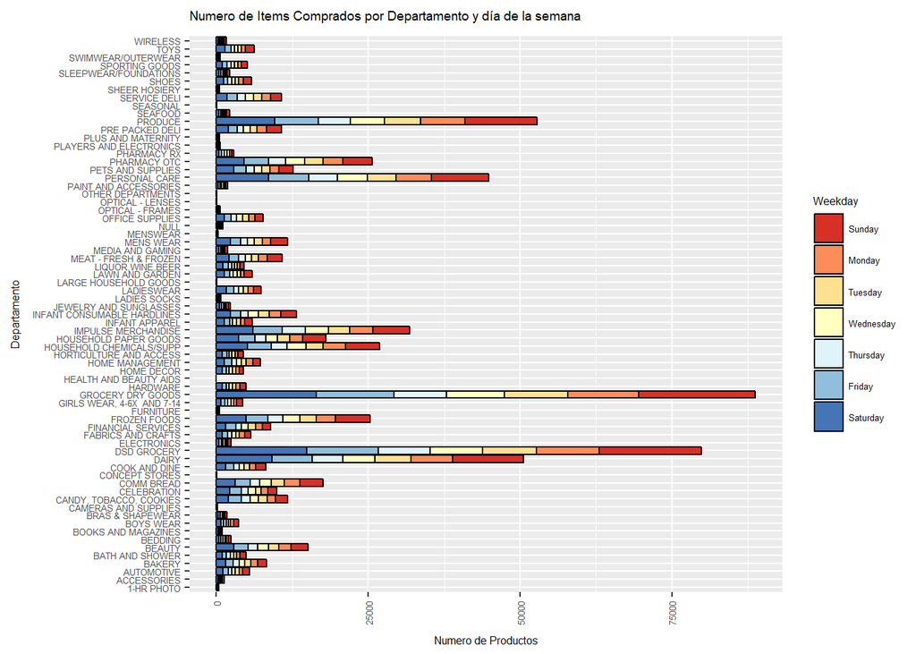

```r
#Tabla Auxiliar con el total Productos Comprados por Departamento
Aux<-train_prep%>%dplyr::group_by(VisitNumber,Weekday,DepartmentDescription)%>%dplyr::summarise(DifferentTripTypes=n_distinct(TripType),ItemsBoughtReturn=sum(ScanCount),ProductsBought=n_distinct(Upc))
Aux$Return<-ifelse(Aux$ItemsBoughtReturn<0,'Yes','No')

Aux<-Aux%>%group_by(Weekday,DepartmentDescription)%>%summarize(DifferentTripTypes=sum(DifferentTripTypes),TotalItemSold=sum(ItemsBoughtReturn))
Aux$Weekday<-factor(Aux$Weekday,levels = c('Sunday','Monday','Tuesday','Wednesday','Thursday','Friday','Saturday'))


p1<-ggplot(data=Aux, aes(x=DepartmentDescription, y=TotalItemSold, fill=Weekday))+geom_bar(colour="black", stat="identity") +
  theme(axis.text.x = element_text(angle = 90, vjust = 0.5, hjust=1)) +
  theme(text = element_text(size = 6)) +
  labs(title = "Numero de Items Comprados por Departamento y día de la semana", x = "Departamento", y = "Numero de Productos") +
  coord_flip()+scale_fill_brewer(palette = "RdYlBu")

p2<-ggplot(data=Aux, aes(x=DepartmentDescription, y=TotalItemSold, fill=Weekday))+geom_bar(colour="black", stat="identity",position="fill") +
  theme(axis.text.x = element_text(angle = 90, vjust = 0.5, hjust=1)) +
  theme(text = element_text(size = 6)) +
  labs(title = "Porcentaje de Items Comprados por Departamento y día de la semana", x = "Departamento", y = "Numero de Productos") +
  coord_flip()+scale_fill_brewer(palette = "RdYlBu")

#grid.arrange(p1,p2,ncol=1)


p1
```

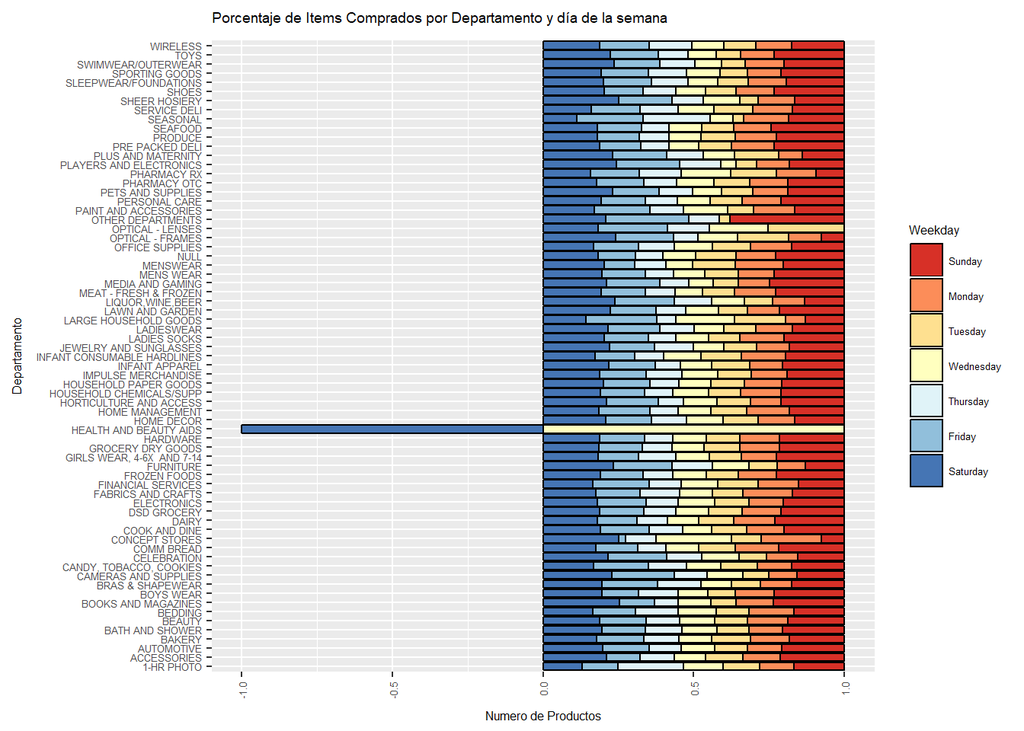

```r
p2
```

<Parece haber algo extraño con el departamento *Health and Beauty Aids* pues parece que **todas** las devoluciones se hicieron en días *Saturday* y **todas** las compras se hicieron en dias *Wednesday*

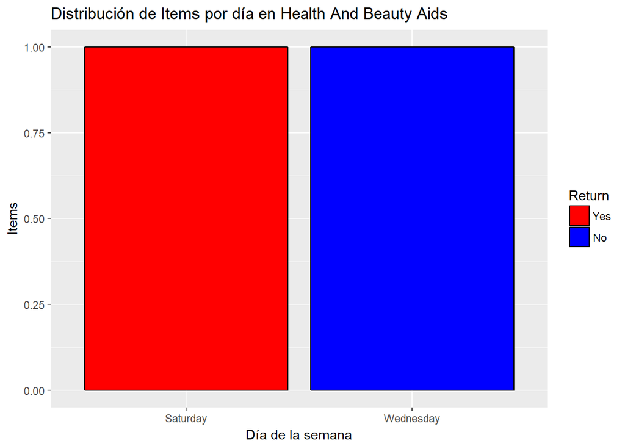

```r
ggplot(train_prep%>%filter(DepartmentDescription=='HEALTH AND BEAUTY AIDS'), aes(x = Weekday, fill=Return)) +
  geom_histogram(colour="black",binwidth = 5,stat="count") +
  ggtitle("Distribución de Items por día en Health And Beauty Aids") +
  xlab("Día de la semana") +
  ylab("Items")+scale_fill_manual(values=c("red","blue"))
```

```r
train_prep%>%filter(DepartmentDescription=='HEALTH AND BEAUTY AIDS')
```

```
## # A tibble: 2 x 7
##   TripType VisitNumber   Weekday    Upc ScanCount  DepartmentDescription
##     <fctr>      <fctr>    <fctr>  <dbl>     <dbl>                 <fctr>
## 1       36      164059 Wednesday 119211         1 HEALTH AND BEAUTY AIDS
## 2      999      182398  Saturday  67984        -1 HEALTH AND BEAUTY AIDS
## # ... with 1 more variables: Return <fctr>
```

En el conjunto de entrenamiento solo se encuentra un item vendido (que fué regresado despues) en ese departamento. Observemos la distribución de items vendidos por día de la semana y departamento sin considerar *Health And Beauty Aids* . La nueva distribución se vería así

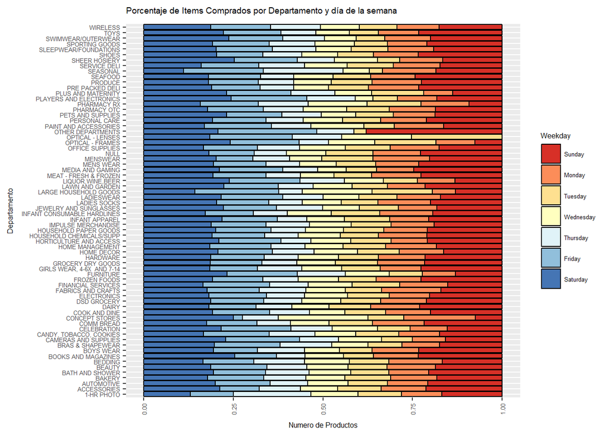

```r
ggplot(data=Aux%>%filter(DepartmentDescription!="HEALTH AND BEAUTY AIDS"), aes(x=DepartmentDescription, y=TotalItemSold, fill=Weekday))+geom_bar(colour="black", stat="identity",position="fill") +
  theme(axis.text.x = element_text(angle = 90, vjust = 0.5, hjust=1)) +
  theme(text = element_text(size = 6)) +
  labs(title = "Porcentaje de Items Comprados por Departamento y día de la semana", x = "Departamento", y = "Numero de Productos") +
  coord_flip()+scale_fill_brewer(palette = "RdYlBu")
```

Sin embargo, el día de la semana parece no aporta información que permita conocer el tipo de departamento (la proporción de los colores en las barras se mantienen constante)

En esta parte se trabaja el total de observaciones de la base de entrenamiento para dejarla en **formato extendido** respecto a la variable `DepartmentDescription`.

```r
Aux<-train_prep%>%dplyr::group_by(VisitNumber)%>%dplyr::summarise(NetItemsBoughtReturn=sum(ScanCount),NetDistinctUpc=n_distinct(Upc))%>%dplyr::arrange(desc(NetItemsBoughtReturn))
#Aux$Return<-ifelse(Aux$ItemsBoughtReturn<0,'Yes','No')
train_clean<-left_join(train_prep,Aux,by='VisitNumber')
train_clean$ReturnVisit<-ifelse(train_clean$ScanCount<0&train_clean$NetDistinctUpc==1,'Yes','No')
train_clean$TripClass<-ifelse(train_clean$TripType==999,'Other-999','IdentifiedTypes')
train_clean%>%dplyr::group_by(ReturnVisit, TripClass)%>%dplyr::summarise(NetItemsBoughtReturn=sum(ScanCount),DistinctUpc=n_distinct(Upc))
```

```
## # A tibble: 4 x 4
## # Groups:   ReturnVisit [?]
##   ReturnVisit       TripClass NetItemsBoughtReturn DistinctUpc
##         <chr>           <chr>                <dbl>       <int>
## 1          No IdentifiedTypes               719455       95468
## 2          No       Other-999                 2707        8269
## 3         Yes IdentifiedTypes                 -175         152
## 4         Yes       Other-999                -4483        2722
```

Nos gustaría poder clasificar a cada tipo de visita de acuerdo a la proporcion de compras en cada departamento, por lo que generamos las variables de porcentaje que representan el número de items de cada observacion en el total de su departamento y el número de códigos de barra distintos. Despues de esto transformaremos la base a formato *spread* con base en la columna `VisitNumber`

```r
dpt_per_visit<-train_prep%>%
  select(c(TripType,Weekday,VisitNumber,DepartmentDescription,ScanCount))%>%
  #filter(VisitNumber%in%-c("7", "8","132","11","21"))%>%
    dplyr::mutate(return=ifelse(ScanCount>0,"b","r"))%>%
  group_by(TripType,Weekday,VisitNumber,DepartmentDescription,return)%>%
  dplyr::summarise(br_prods=sum(abs(ScanCount)))

aux<-train_prep%>%
  select(c(TripType,Weekday,VisitNumber,DepartmentDescription,ScanCount))%>%
  #filter(VisitNumber%in%-c("7", "8","132","11","21"))%>%
  group_by(TripType,Weekday,VisitNumber)%>%
  dplyr::summarise(tot_prods=sum(abs(ScanCount)))

dpt_per_visit2 <- left_join(dpt_per_visit, aux) %>%
  mutate(share=br_prods/tot_prods)


dpt_per_visit2$DepartmentDescription<-as.character(dpt_per_visit2$DepartmentDescription)
dpt_per_visit2$DepartmentDescAux<-ifelse(dpt_per_visit2$return=='r','RETURN',dpt_per_visit2$DepartmentDescription)
dpt_per_visit2$DepartmentDescription<-as.character(dpt_per_visit2$DepartmentDescription)

dpt_per_visit3<-dpt_per_visit2[,c("TripType","Weekday","VisitNumber","DepartmentDescAux","tot_prods","share")]

dpt_per_visit3$DepartmentDescAux<-as.factor(dpt_per_visit3$DepartmentDescAux)

dpt_per_visit4<-dpt_per_visit3 %>%
  select("TripType","Weekday","VisitNumber","DepartmentDescAux","tot_prods","share") %>%
  group_by(VisitNumber,DepartmentDescAux,TripType,Weekday,tot_prods) %>%
  dplyr::summarise(max_share=max(share)) %>%
  tidyr::spread(DepartmentDescAux,max_share,fill=0)

write.csv(dpt_per_visit4,"dpt_per_visit.csv",row.names = FALSE)
```